# Different types of network

Matthew Silk

2022-05-11

### Here we provide an overview of how to use `netGenDem` to simulate different types of network.

#### First we load the package

```r
library(genNetDem)
library(asnipe)
library(igraph)
library(sna)
library(viridis)
```

#### We now set up a first population and network.

We generate a population of 100 individuals without underlying group structure.

```r
#Generate population
pop_info<-population_generation_basic(n=100,ng=100,plot=FALSE)
indiv_data<-pop_info[[1]]
dist_mat<-pop_info[[2]]
```

We simulate the traits sex and size.

```r
indiv_info<-data.frame(indiv_data$indivs)
indiv_info<-indiv_info_gen(indiv_info,ii_tag=NULL,indiv_data=indiv_data,trait="sex",trait_type="fac",level_names=c("M","F"))
indiv_info<-indiv_info_gen(indiv_info[[1]],ii_tag=indiv_info[[2]],indiv_data,trait="size",trait_type="cov",x_dist="norm")
```

We generate a network using a similar strategy to in our overall example but this time with: a) a lower intercept connection density; b) only an effect of sex on the likelihood and weight of connections (and not an effect of size); and c) a stronger sex effect than previously.

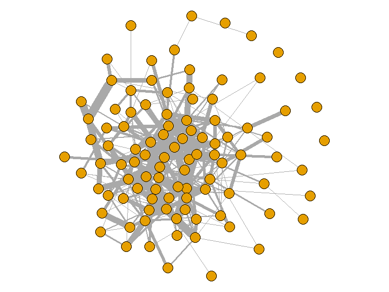

```r
effs<-list()
effs[[1]]<-matrix(c(0,0,0,2,2,0,0,0),nr=1,nc=8)
effs[[1]]<-rbind(rep(0,8),effs[[1]])
effs[[2]]<-matrix(c(0,0,0,0,0,0,0,0),nr=1,nc=8)

net_info<-network_generation_covariates(indiv_data,dist_mat,indiv_info,
                                        p_ig=0.2,wi_m=0.25,wi_v=0.025,
                                        p_og=0.05,wo_m=0.25,wo_v=0.025,
                                        d_effp=8,d_effw=8,
                                        covs=c(2,3),effs=effs,
                                        plot=TRUE)
```

```r
pop_mat<-net_info[[1]]
pop_net<-net_info[[2]]
```

The default plot from `network_generation_covariates()` doesn’t show us much but if we plot the network ourselves and calculate some basic social network measures we can see the effects we included.

The first panel shows that males (red) tend to be much closer to the centre of the graph as they are much more strongly socially connected than females.

The second panel shows that males have much higher eigenvector centrality than females because of having more and stronger connections.

The third panel shows no effect of size on degree centrality.

The fourth panel shows the strong effect of distance on the probability of a social connection and its strength when it exists.

```r
par(mfrow=c(4,1))
cols<-rep("blue",nrow(indiv_info[[1]]))
cols[indiv_info[[1]]$sex=="M"]<-"red"
plot(pop_net,vertex.label=NA,vertex.color=cols)

boxplot(igraph::eigen_centrality(pop_net)$vector~indiv_info[[1]]$sex,range=0,lty=1,xlab="Sex",ylab="Eigenvector Centrality",cex.lab=1.5,cex.axis=1.5)

plot(igraph::degree(pop_net)~indiv_info[[1]]$size,xlab="Size",ylab="Degree",pch=16,cex.lab=1.5,cex.axis=1.5)

plot(pop_mat[pop_mat>0]~dist_mat[pop_mat>0],pch=16,col=adjustcolor("firebrick",0.5),xlab="Distance Apart",ylab="Association Strength",xlim=c(0,1.5),cex.lab=1.5,cex.axis=1.5)

A<-hist(dist_mat[pop_mat==0],breaks=seq(0,1.5,0.1),plot=FALSE)
B<-hist(dist_mat,breaks=seq(0,1.5,0.1),plot=FALSE)

A$counts/B$counts
```

```
#>  [1] 0.8990826 0.9119171 0.9225225 0.9090909 0.9411765 0.9597523 0.9654605
#>  [8] 0.9628942 0.9922680 0.9906977 0.9795918 1.0000000 0.8333333       NaN
#> [15]       NaN
```

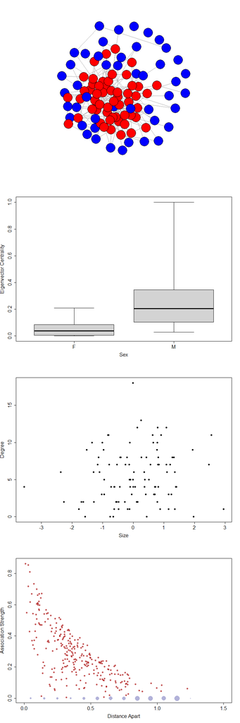

```r
points(x=seq(0.05,1.45,0.1),y=rep(0,15),cex=3.5*(A$counts/B$counts)^10,pch=16,col=adjustcolor("navy",0.3))
```

Alternatively, we could assume that our population is well-mixed so that distance apart is not important for underlying social relationships. Here we build a network where distance effects are much weaker but depend on the size of individuals — bigger individuals have more spatially-structured social relationships.

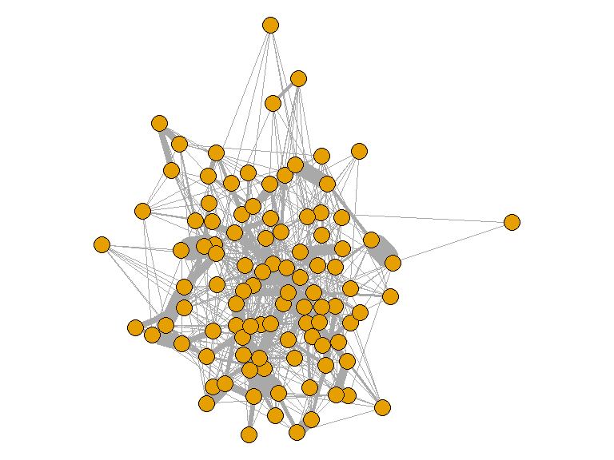

```r
effs<-list()
effs[[1]]<-matrix(c(0,0,0,0,0,0,0,0),nr=1,nc=8)
effs[[1]]<-rbind(rep(0,8),effs[[1]])
effs[[2]]<-matrix(c(0,0,0,0,0,0,0.5,0),nr=1,nc=8)

net_info<-network_generation_covariates(indiv_data,dist_mat,indiv_info,
                                        p_ig=0.2,wi_m=0.25,wi_v=0.025,
                                        p_og=0.1,wo_m=0.1,wo_v=0.025,
                                        d_effp=0,d_effw=0,
                                        covs=c(2,3),effs=effs,
                                        plot=TRUE)
```

```r
pop_mat<-net_info[[1]]
pop_net<-net_info[[2]]
```

Here we plot the network, with the node size related to their size in real (simulated) life. We can again plot the relationship between distance and social relationship strength, illustrating that this effect is now much weaker. Finally we can plot the relationship between size and degree, to show that size differences in the distance effect have minimal effect on how connected individuals are in this example.

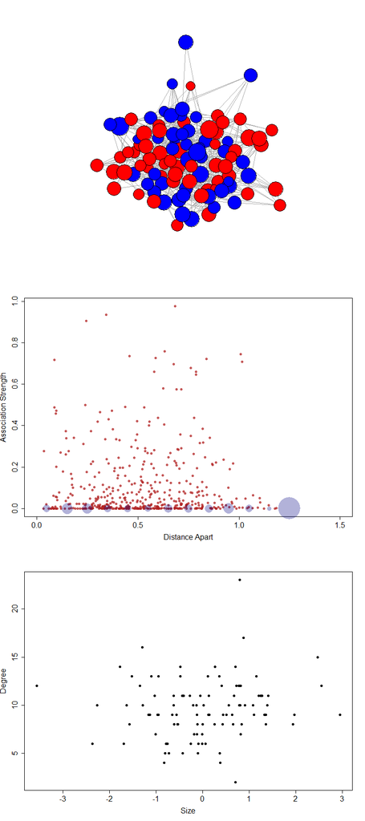

```r
par(mfrow=c(3,1))
cols<-rep("blue",nrow(indiv_info[[1]]))
cols[indiv_info[[1]]$sex=="M"]<-"red"
plot(pop_net,vertex.label=NA,vertex.color=cols,vertex.size=2*indiv_info[[1]]$size+15)

plot(pop_mat[pop_mat>0]~dist_mat[pop_mat>0],pch=16,col=adjustcolor("firebrick",0.5),xlab="Distance Apart",ylab="Association Strength",xlim=c(0,1.5),cex.lab=1.5,cex.axis=1.5)

A<-hist(dist_mat[pop_mat==0],breaks=seq(0,1.5,0.1),plot=FALSE)
B<-hist(dist_mat,breaks=seq(0,1.5,0.1),plot=FALSE)

points(x=seq(0.05,1.45,0.1),y=rep(0,15),cex=10*(A$counts/B$counts)^10,pch=16,col=adjustcolor("navy",0.3))

plot(igraph::degree(pop_net)~indiv_info[[1]]$size,xlab="Size",ylab="Degree",pch=16,cex.lab=1.5,cex.axis=1.5)
```

#### We now set up a second population and network.

This time we include an underlying group structure. Our population of 100 individuals is divided into 10 different groups.

```r
#Generate population
pop_info<-population_generation_basic(n=100,ng=10,plot=FALSE)
indiv_data<-pop_info[[1]]
dist_mat<-pop_info[[2]]
```

We simulate the traits sex and size.

```r
indiv_info<-data.frame(indiv_data$indivs)
indiv_info<-indiv_info_gen(indiv_info,ii_tag=NULL,indiv_data=indiv_data,trait="sex",trait_type="fac",level_names=c("M","F"))
indiv_info<-indiv_info_gen(indiv_info[[1]],ii_tag=indiv_info[[2]],indiv_data,trait="size",trait_type="cov",x_dist="norm")
```

We can now make social networks that have strong group-based structure. To illustrate here we create a network with a high-likelihood of strong within-group connections and only weak between-group connections that are strongly spatially structured.

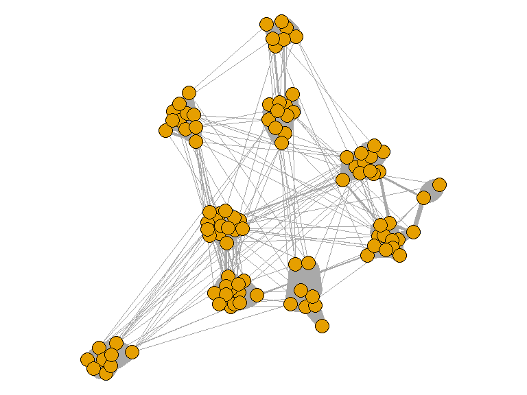

```r
effs<-list()
effs[[1]]<-matrix(c(0,0,0,0,0,0,0,0),nr=1,nc=8)
effs[[1]]<-rbind(rep(0,8),effs[[1]])
effs[[2]]<-matrix(c(0,0,0,0,0,0,0,0),nr=1,nc=8)

net_info<-network_generation_covariates(indiv_data,dist_mat,indiv_info,
                                        p_ig=0.8,wi_m=0.5,wi_v=0.05,
                                        p_og=0.1,wo_m=0.1,wo_v=0.025,
                                        d_effp=8,d_effw=8,
                                        covs=c(2,3),effs=effs,
                                        plot=TRUE)
```

```r
pop_mat<-net_info[[1]]
pop_net<-net_info[[2]]
```

We can illustrate the social group structure nicely with some more refined network plotting code

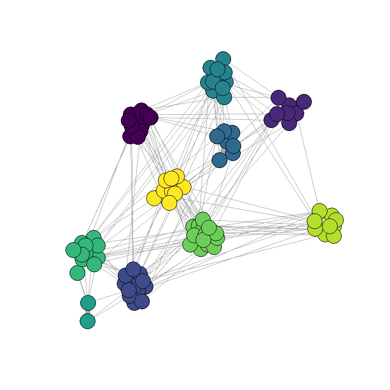

```r
par(mfrow=c(1,1))
cols<-viridis(10)
plot(pop_net,vertex.label=NA,vertex.color=cols[indiv_data$groups],vertex.size=12,edge.width=(igraph::E(pop_net)$weight*5)^1.5)
```

Because of how `network_generation_covariates` is designed we can simulate different effects of node traits on edges within- vs. between-groups. For example here we set males to have stronger between group connections and weaker within-group connections

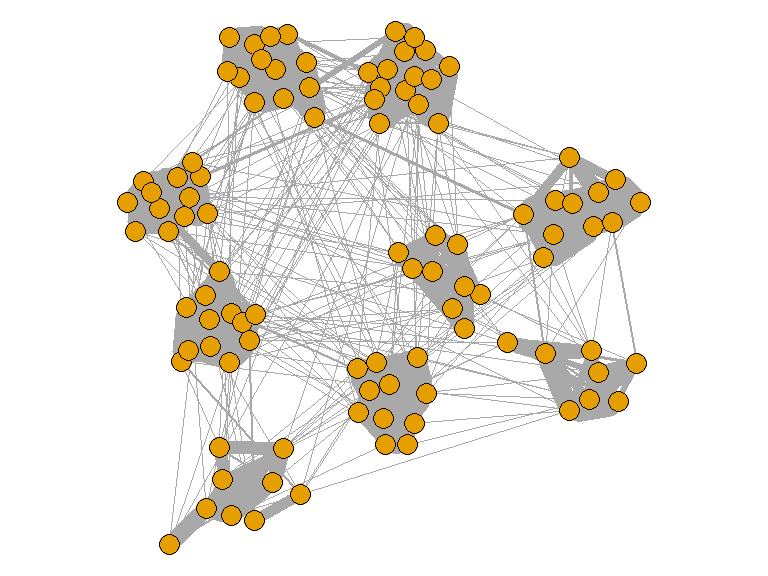

```r
effs<-list()
effs[[1]]<-matrix(c(-0.1,-0.25,0,0.2,0.5,0,-2,0),nr=1,nc=8)
effs[[1]]<-rbind(rep(0,8),effs[[1]])
effs[[2]]<-matrix(c(0,0,0,0,0,0,0,0),nr=1,nc=8)

net_info<-network_generation_covariates(indiv_data,dist_mat,indiv_info,
                                        p_ig=0.8,wi_m=0.5,wi_v=0.05,
                                        p_og=0.1,wo_m=0.1,wo_v=0.025,
                                        d_effp=8,d_effw=8,
                                        covs=c(2,3),effs=effs,
                                        plot=TRUE)
```

```r
pop_mat<-net_info[[1]]
pop_net<-net_info[[2]]
```

The network plot instantly shows that the males tendency to form more between-group connections leads to groups having more edges between them. We can then show that this difference in behaviour leads to males tending to have higher betweenness centrality (importance in connecting different parts of the network) than females/

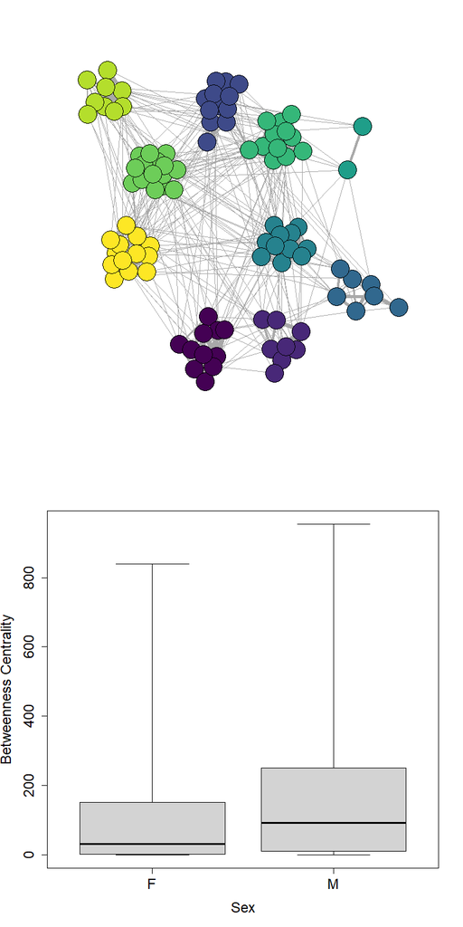

```r
par(mfrow=c(2,1))
cols<-viridis(10)
plot(pop_net,vertex.label=NA,vertex.color=cols[indiv_data$groups],vertex.size=12,edge.width=(igraph::E(pop_net)$weight*5)^1.5)

boxplot(igraph::betweenness(pop_net,weights=1/E(pop_net)$weight)~indiv_info[[1]]$sex,xlab="Sex",ylab="Betweenness Centrality",range=0,lty=1,pch=16,cex.lab=1.5,cex.axis=1.5)
```